# Untitled

Important links:

https://medium.com/geo-university-learning-content/credit-card-fraud-detection-using-keras-and-r-d1fa59a7326

https://data-flair.training/blogs/data-science-machine-learning-project-credit-card-fraud-detection/

https://colab.research.google.com/drive/1PPaz2eAtOZBDx9R9syQFP1F2gZ3Anhou?authuser=2#scrollTo=lEOnNYagguZF

6 files to upload on Github:

readme = equalvlent to html file except that all plots I will take them as screenshots. html file rmd file report when I explian everything in analyizing way small guidelines with external links wiki libraries with small descriptions. csv file the data that I have used.

## Credit Card Fraud Detection

The goal of this module is to detect credit card fraudulent transactions, and it’s better to be familiar with machine learning algorithms concepts before I start:

1. Logistic regression
2. Decision trees
3. Neural network

Also I have uploaded the datset that I have used in this module.

Final steps these are the basic libraries that I need them. although there are more libraries needed here. I will mention them all during the journey!

```r
# Loading the required libraries, although there are more libraries needed here. I will mention them all during the journey!

library(ggplot2)
library(lattice)
library(caret)
library(ranger)
library(data.table)
```

### 1. First step is importing the dataset, and understand the dataset. What’s represents, identify the variables.

Understanding which numbers are continuous also comes in handy when thinking about the type of plot to use to represent your data visually.

It might find some descriptive data analysis as well. It is crucial **to know all the values, observations and missing values.** As it will help later with the outliers and plots. Even counting the NA values can help with the dataset.

```r
df1.0 <- read.csv("creditcard.csv")
head(df1.0, 5)
```

```
##   Time         V1          V2        V3         V4          V5          V6
## 1    0 -1.3598071 -0.07278117 2.5363467  1.3781552 -0.33832077  0.46238778
## 2    0  1.1918571  0.26615071 0.1664801  0.4481541  0.06001765 -0.08236081
## 3    1 -1.3583541 -1.34016307 1.7732093  0.3797796 -0.50319813  1.80049938
## 4    1 -0.9662717 -0.18522601 1.7929933 -0.8632913 -0.01030888  1.24720317
## 5    2 -1.1582331  0.87773675 1.5487178  0.4030339 -0.40719338  0.09592146
##            V7          V8         V9         V10        V11         V12
## 1  0.23959855  0.09869790  0.3637870  0.09079417 -0.5515995 -0.61780086
## 2 -0.07880298  0.08510165 -0.2554251 -0.16697441  1.6127267  1.06523531
## 3  0.79146096  0.24767579 -1.5146543  0.20764287  0.6245015  0.06608369
## 4  0.23760894  0.37743587 -1.3870241 -0.05495192 -0.2264873  0.17822823
## 5  0.59294075 -0.27053268  0.8177393  0.75307443 -0.8228429  0.53819555
##          V13        V14        V15        V16        V17         V18        V19
## 1 -0.9913898 -0.3111694  1.4681770 -0.4704005  0.2079712  0.02579058  0.4039930
## 2  0.4890950 -0.1437723  0.6355581  0.4639170 -0.1148047 -0.18336127 -0.1457830
## 3  0.7172927 -0.1659459  2.3458649 -2.8900832  1.1099694 -0.12135931 -2.2618571
## 4  0.5077569 -0.2879237 -0.6314181 -1.0596472 -0.6840928  1.96577500 -1.2326220
## 5  1.3458516 -1.1196698  0.1751211 -0.4514492 -0.2370332 -0.03819479  0.8034869
##           V20          V21          V22        V23         V24        V25
## 1  0.25141210 -0.018306778  0.277837576 -0.1104739  0.06692807  0.1285394
## 2 -0.06908314 -0.225775248 -0.638671953  0.1012880 -0.33984648  0.1671704
## 3  0.52497973  0.247998153  0.771679402  0.9094123 -0.68928096 -0.3276418
## 4 -0.20803778 -0.108300452  0.005273597 -0.1903205 -1.17557533  0.6473760
## 5  0.40854236 -0.009430697  0.798278495 -0.1374581  0.14126698 -0.2060096
##          V26          V27         V28 Amount Class
## 1 -0.1891148  0.133558377 -0.02105305 149.62     0
## 2  0.1258945 -0.008983099  0.01472417   2.69     0
## 3 -0.1390966 -0.055352794 -0.05975184 378.66     0
## 4 -0.2219288  0.062722849  0.06145763 123.50     0
## 5  0.5022922  0.219422230  0.21515315  69.99     0
```

### 2. Manipulate our dataset.

It’s an advanced level of understand our dataset. Any analyst finds himself/herself spending the biggest time of doing the project in these two steps. Real datasets are really messy and need a lot of attention and efforts. The rest such as picking up the model or visualizing your data is a light typing (visualizing/plotting doesn’t take more than 5 lines of coding!).

As you can see we have time variable, 28V variable and amount variable. Also we have class variable. What I mean by variable is column. Observation is a row. Finally value is the number or output in one cell.

Now I will use summary() function to generate some numerical values. **It is really great to see that we have the basic outputs such as the mean, median, 25% quantile, 75% quantile, min & max values in the dataset.** I can use these results to compare between values or even as a benchmark.

```r
summary(df1.0)
```

```
##       Time              V1                  V2                  V3
##  Min.   :     0   Min.   :-56.40751   Min.   :-72.71573   Min.   :-48.3256
##  1st Qu.: 54202   1st Qu.: -0.92037   1st Qu.: -0.59855   1st Qu.: -0.8904
##  Median : 84692   Median :  0.01811   Median :  0.06549   Median :  0.1799
##  Mean   : 94814   Mean   :  0.00000   Mean   :  0.00000   Mean   :  0.0000
##  3rd Qu.:139320   3rd Qu.:  1.31564   3rd Qu.:  0.80372   3rd Qu.:  1.0272
##  Max.   :172792   Max.   :  2.45493   Max.   : 22.05773   Max.   :  9.3826
##        V4                 V5                   V6                 V7
##  Min.   :-5.68317   Min.   :-113.74331   Min.   :-26.1605   Min.   :-43.5572
##  1st Qu.:-0.84864   1st Qu.:  -0.69160   1st Qu.: -0.7683   1st Qu.: -0.5541
##  Median :-0.01985   Median :  -0.05434   Median : -0.2742   Median :  0.0401
##  Mean   : 0.00000   Mean   :   0.00000   Mean   :  0.0000   Mean   :  0.0000
##  3rd Qu.: 0.74334   3rd Qu.:   0.61193   3rd Qu.:  0.3986   3rd Qu.:  0.5704
##  Max.   :16.87534   Max.   :  34.80167   Max.   : 73.3016   Max.   :120.5895
##        V8                  V9                 V10                 V11
##  Min.   :-73.21672   Min.   :-13.43407   Min.   :-24.58826   Min.   :-4.79747
##  1st Qu.: -0.20863   1st Qu.: -0.64310   1st Qu.: -0.53543   1st Qu.:-0.76249
##  Median :  0.02236   Median : -0.05143   Median : -0.09292   Median :-0.03276
##  Mean   :  0.00000   Mean   :  0.00000   Mean   :  0.00000   Mean   : 0.00000
##  3rd Qu.:  0.32735   3rd Qu.:  0.59714   3rd Qu.:  0.45392   3rd Qu.: 0.73959
##  Max.   : 20.00721   Max.   : 15.59500   Max.   : 23.74514   Max.   :12.01891
##       V12                V13                V14                V15
##  Min.   :-18.6837   Min.   :-5.79188   Min.   :-19.2143   Min.   :-4.49894
##  1st Qu.: -0.4056   1st Qu.:-0.64854   1st Qu.: -0.4256   1st Qu.:-0.58288
##  Median :  0.1400   Median :-0.01357   Median :  0.0506   Median : 0.04807
##  Mean   :  0.0000   Mean   : 0.00000   Mean   :  0.0000   Mean   : 0.00000
##  3rd Qu.:  0.6182   3rd Qu.: 0.66251   3rd Qu.:  0.4931   3rd Qu.: 0.64882
##  Max.   :  7.8484   Max.   : 7.12688   Max.   : 10.5268   Max.   : 8.87774
##       V16                 V17                 V18
##  Min.   :-14.12985   Min.   :-25.16280   Min.   :-9.498746
##  1st Qu.: -0.46804   1st Qu.: -0.48375   1st Qu.:-0.498850
##  Median :  0.06641   Median : -0.06568   Median :-0.003636
##  Mean   :  0.00000   Mean   :  0.00000   Mean   : 0.000000
##  3rd Qu.:  0.52330   3rd Qu.:  0.39968   3rd Qu.: 0.500807
##  Max.   : 17.31511   Max.   :  9.25353   Max.   : 5.041069
##       V19                 V20                 V21
##  Min.   :-7.213527   Min.   :-54.49772   Min.   :-34.83038
##  1st Qu.:-0.456299   1st Qu.: -0.21172   1st Qu.: -0.22839
##  Median : 0.003735   Median : -0.06248   Median : -0.02945
##  Mean   : 0.000000   Mean   :  0.00000   Mean   :  0.00000
```

[output cut: 8 more lines]

```
##  Max.   : 10.503090   Max.   : 22.52841   Max.   : 4.58455
##       V25                 V26                V27
##  Min.   :-10.29540   Min.   :-2.60455   Min.   :-22.565679
##  1st Qu.: -0.31715   1st Qu.:-0.32698   1st Qu.: -0.070840
##  Median :  0.01659   Median :-0.05214   Median :  0.001342
##  Mean   :  0.00000   Mean   : 0.00000   Mean   :  0.000000
##  3rd Qu.:  0.35072   3rd Qu.: 0.24095   3rd Qu.:  0.091045
##  Max.   :  7.51959   Max.   : 3.51735   Max.   : 31.612198
##       V28                Amount             Class
##  Min.   :-15.43008   Min.   :    0.00   Min.   :0.000000
##  1st Qu.: -0.05296   1st Qu.:    5.60   1st Qu.:0.000000
##  Median :  0.01124   Median :   22.00   Median :0.000000
##  Mean   :  0.00000   Mean   :   88.35   Mean   :0.001728
##  3rd Qu.:  0.07828   3rd Qu.:   77.17   3rd Qu.:0.000000
##  Max.   : 33.84781   Max.   :25691.16   Max.   :1.000000
```

```r
df1.0$Amount=scale(df1.0$Amount)
df=df1.0[,-c(1)]
head(df)
```

```
##           V1          V2        V3         V4          V5          V6
## 1 -1.3598071 -0.07278117 2.5363467  1.3781552 -0.33832077  0.46238778
## 2  1.1918571  0.26615071 0.1664801  0.4481541  0.06001765 -0.08236081
## 3 -1.3583541 -1.34016307 1.7732093  0.3797796 -0.50319813  1.80049938
## 4 -0.9662717 -0.18522601 1.7929933 -0.8632913 -0.01030888  1.24720317
## 5 -1.1582331  0.87773675 1.5487178  0.4030339 -0.40719338  0.09592146
## 6 -0.4259659  0.96052304 1.1411093 -0.1682521  0.42098688 -0.02972755
##            V7          V8         V9         V10        V11         V12
## 1  0.23959855  0.09869790  0.3637870  0.09079417 -0.5515995 -0.61780086
## 2 -0.07880298  0.08510165 -0.2554251 -0.16697441  1.6127267  1.06523531
## 3  0.79146096  0.24767579 -1.5146543  0.20764287  0.6245015  0.06608369
## 4  0.23760894  0.37743587 -1.3870241 -0.05495192 -0.2264873  0.17822823
## 5  0.59294075 -0.27053268  0.8177393  0.75307443 -0.8228429  0.53819555
## 6  0.47620095  0.26031433 -0.5686714 -0.37140720  1.3412620  0.35989384
##          V13        V14        V15        V16         V17         V18
```

[output cut: 20 more lines]

### 3. Modelling the data we have:

shorten this tip!!

The set. seed() function sets the starting number used to generate a sequence of random numbers – it ensures that you get the same result if you start with that same seed each time you run the same process. For example, if I use the sample() function immediately after setting a seed, I will always get the same sample.

```r
# Import the "caTools" library
library(caTools)
set.seed(123)
```

```r
data_smaple = sample.split(df$Class, SplitRatio = 0.80)

train_df = subset(df, data_smaple == TRUE)
test_df = subset(df, data_smaple == FALSE)
```

```r
dim(train_df)
```

```
## [1] 227846     30
```

```r
dim(test_df)
```

```
## [1] 56961    30
```

```r
logistic_model=glm(Class~.,test_df,family=binomial())
summary(logistic_model)
```

```
##
## Call:
## glm(formula = Class ~ ., family = binomial(), data = test_df)
##
## Deviance Residuals:
##     Min       1Q   Median       3Q      Max
## -4.9019  -0.0254  -0.0156  -0.0078   4.0877
##
## Coefficients:
##              Estimate Std. Error z value Pr(>|z|)
## (Intercept) -12.52800   10.30537  -1.216   0.2241
## V1           -0.17299    1.27381  -0.136   0.8920
## V2            1.44512    4.23062   0.342   0.7327
## V3            0.17897    0.24058   0.744   0.4569
## V4            3.13593    7.17768   0.437   0.6622
## V5            1.49014    3.80369   0.392   0.6952
## V6           -0.12428    0.22202  -0.560   0.5756
## V7            1.40903    4.22644   0.333   0.7388
## V8           -0.35254    0.17462  -2.019   0.0435 *
## V9            3.02176    8.67262   0.348   0.7275
## V10          -2.89571    6.62383  -0.437   0.6620
## V11          -0.09769    0.28270  -0.346   0.7297
## V12           1.97992    6.56699   0.301   0.7630
## V13          -0.71674    1.25649  -0.570   0.5684
## V14           0.19316    3.28868   0.059   0.9532
## V15           1.03868    2.89256   0.359   0.7195
## V16          -2.98194    7.11391  -0.419   0.6751
## V17          -1.81809    4.99764  -0.364   0.7160
## V18           2.74772    8.13188   0.338   0.7354
## V19          -1.63246    4.77228  -0.342   0.7323
## V20          -0.69925    1.15114  -0.607   0.5436
## V21          -0.45082    1.99182  -0.226   0.8209
## V22          -1.40395    5.18980  -0.271   0.7868
## V23           0.19026    0.61195   0.311   0.7559
## V24          -0.12889    0.44701  -0.288   0.7731
## V25          -0.57835    1.94988  -0.297   0.7668
## V26           2.65938    9.34957   0.284   0.7761
## V27          -0.45396    0.81502  -0.557   0.5775
## V28          -0.06639    0.35730  -0.186   0.8526
## Amount        0.22576    0.71892   0.314   0.7535
## ---
## Signif. codes:  0 '***' 0.001 '**' 0.01 '*' 0.05 '.' 0.1 ' ' 1
##
## (Dispersion parameter for binomial family taken to be 1)
##
##     Null deviance: 1443.40  on 56960  degrees of freedom
## Residual deviance:  378.59  on 56931  degrees of freedom
## AIC: 438.59
##
## Number of Fisher Scoring iterations: 17
```

Better to add some explain everything

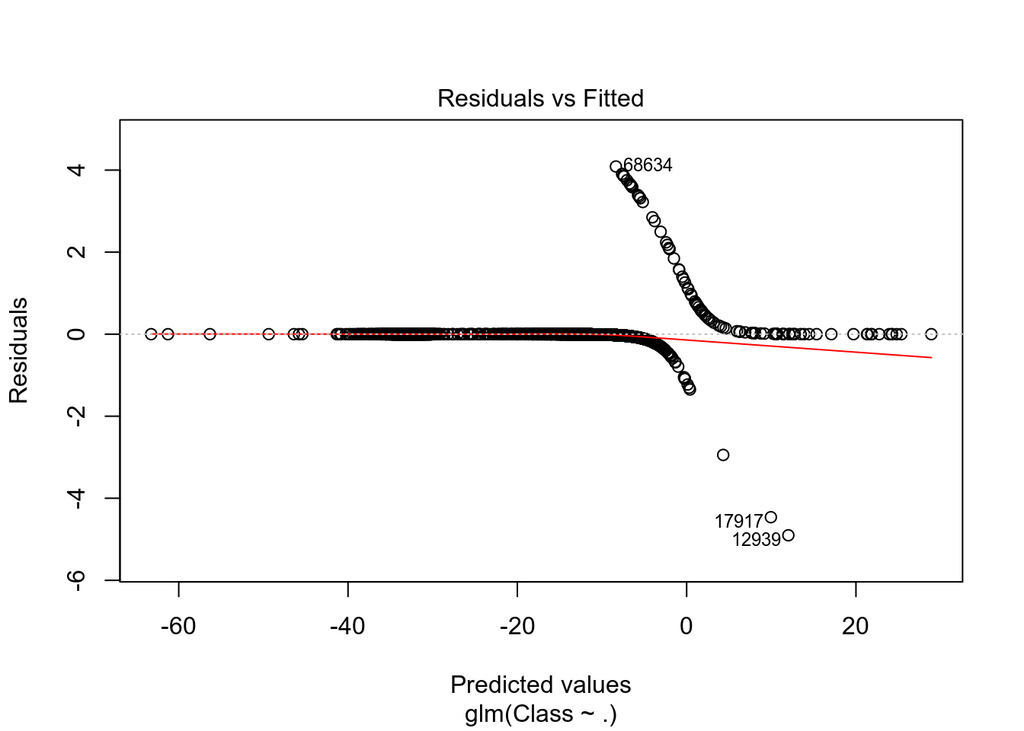

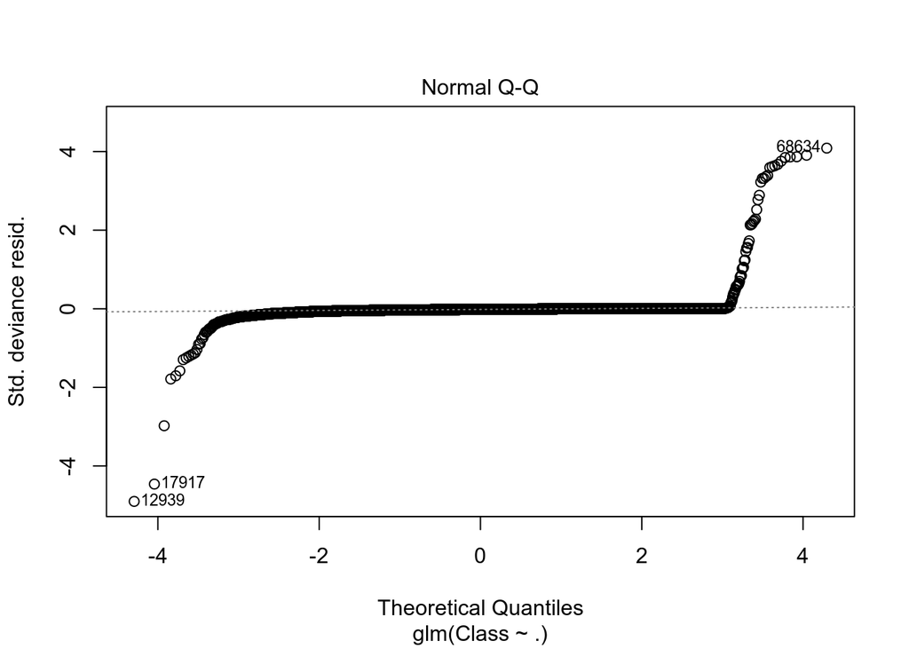

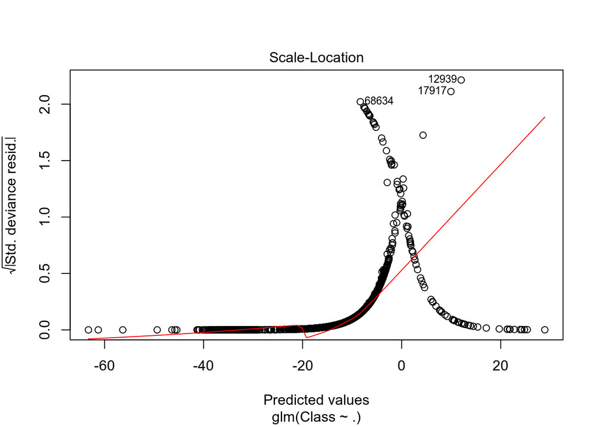

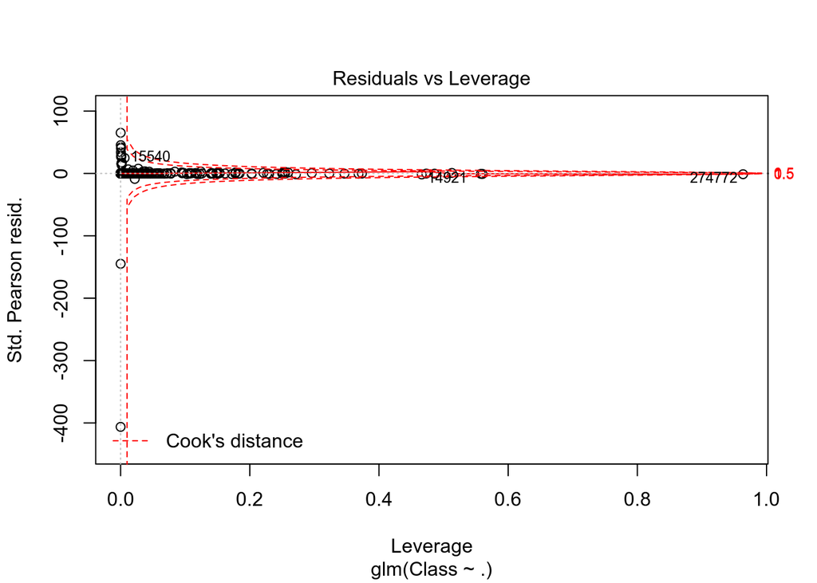

```r
plot(logistic_model)
```

```r
library(rpart)
library(rpart.plot)
```

```r
decision_tree_model <- rpart(df$Class ~ . , df, method = "class")
predicted_val <- predict(decision_tree_model, df, type = "class")
probability <- predict(decision_tree_model, df, type = "prob")
```

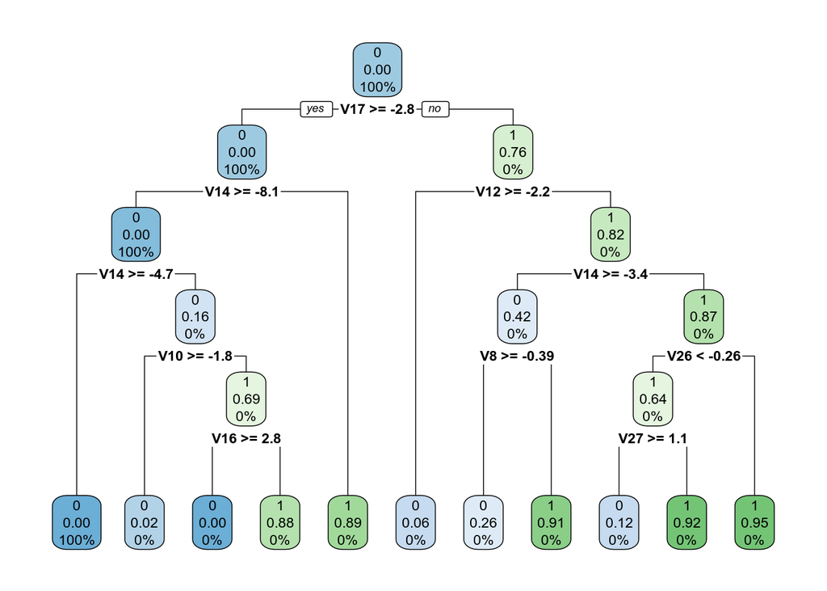

```r
rpart.plot(decision_tree_model)
```

### 7. Artificial Neural Network:

**act.fct.:** a differentiable function that is used for smoothing the result of the cross product of the covariate or neurons and the weights. (more information can be found in this link: https://www.rdocumentation.org/packages/neuralnet/versions/1.44.2/topics/neuralnet)

```r
# Import [neuralnet] library in order to show the data based on the historical data
# and are able to perform classification on the input data.
library(neuralnet)

# Creating my ANN_model using neuralent function. I have marked linear.output as FALSE because
# act.fct should not be applied to the output neurons
ANN_model = neuralnet(Class ~ ., train_df, linear.output = FALSE)
plot(ANN_model)
```

[output not shown]

need some clarifications herre

```r
predANN = compute(ANN_model, test_df)
resultANN = predANN$net.result
resultANN = ifelse(resultANN > 0.5, 1, 0)
```

```r
library(gbm, quietly = TRUE)
# Use the GBM model

system.time(
  model_gbm <- gbm(Class ~ .
                   , distribution = "bernoulli"
                   , data = rbind(train_df, test_df)
                   , n.trees = 500
                   , interaction.depth = 3
                   , n.minobsinnode = 100
                   , shrinkage = 0.0
                   , bag.fraction = 0.5
                   , train.fraction = nrow(train_df) / (nrow(train_df) + nrow(test_df))
                   )
)
```

```
##    user  system elapsed
## 297.510   0.120 297.664
```

```r
# Determine best iteration based on test data
gbm.iter = gbm.perf(model_gbm, method = "test")
```

[figure not shown]

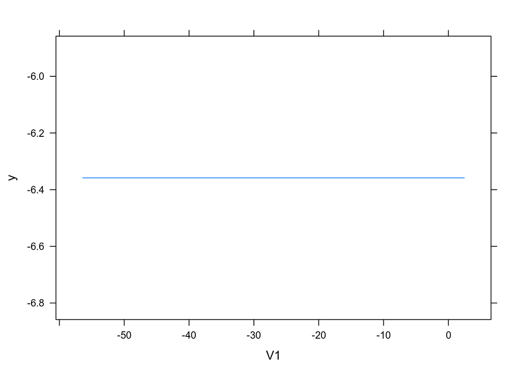

```r
model.influence = relative.influence(model_gbm, n.trees = gbm.iter, sort. = TRUE)

# Visualize the GBM model
plot(model_gbm)
```

```r
library(pROC)
```

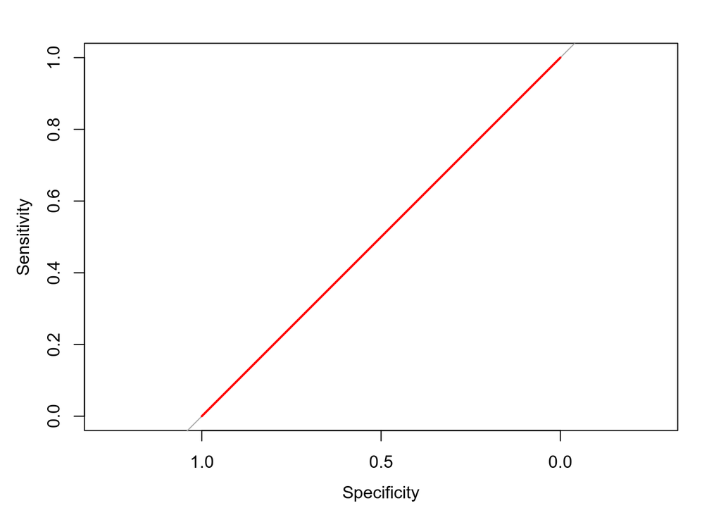

```r
# Plot and calculate AUC on test data
gbm_test = predict(model_gbm, newdata = test_df, n.trees = gbm.iter)
gbm_auc = roc(test_df$Class, gbm_test, plot = TRUE, col = "red")
```

```r
print(gbm_auc)
```

```
##
## Call:
## roc.default(response = test_df$Class, predictor = gbm_test, plot = TRUE,     col = "red")
##
## Data: gbm_test in 56863 controls (test_df$Class 0) < 98 cases (test_df$Class 1).
## Area under the curve: 0.5
```